# Example Plots

Heath Blackmon

2/13/2018

## General consideration

As we discussed in class honest depiction and not misleading your reader should be your first concern when designing a figure. After that telling a story so that your reader can use the figures to better understand your science is the next most important function of a figure. Here are a few rules adapted from [Edward Tufte's work](https://www.amazon.com/Edward-R.-Tufte/e/B000APET3Y) to help you:

1. Keep the ink to information ratio high. Ask yourself whether each element of your plot is providing additional information or helping your reader understand your data.
2. Show your actual data!
3. Avoid chart-junk - these are things like 3 dimensional bars in a barplot. Excel and similar automated programs make these easy to produce. Unfortunately, they often obfuscate the relationships being plotted.
4. User color wisely - picking a color scheme throughout your manuscript can help a reader interpret plots quickly. Adding color just for aesthetics is often a mistake. Remember some people will print your paper in black and white. If someone cares enough to print you paper make sure they will be able to understand your plots.
5. Learn your field! Every sub-discipline has its own typical ways of displaying certain kinds of results. Going against this can lead to your paper spending more time in review than is necessary.

## An example from class

In the remainder of this page I am going to build two versions of the same plot. These plots are displaying our posterior distribution of the substitution rates in the three codons of our DNA alignment. What you will see is that I tend to build up a figure from a lot of little individual pieces. I usually don’t use the ready made functions like boxplot and I often suppress axes and other components and instead add them piece by piece to make the plot look just how I want it to.

```r
# First we set the working directory
setwd("~/Desktop/Dropbox/gitrepos/coleoguy.github.io/teaching/expdes/hw-labs/data")

# now we read in the data
dat <- read.csv("mcmc.log.csv")

# I want to use the coda package to get HPDs
library(coda)

# I want to create a table that has the means, and low and high end of
# the credible interval of our posterior distributions (you can think of
# this as our 95% CI)
dat.sum <- as.data.frame(matrix(,3,3))
colnames(dat.sum) <- colnames(dat)[3:5]
row.names(dat.sum) <- c("mean", "low", "high")
dat.sum[1, ] <- c(mean(dat$codon1),
                  mean(dat$codon2),
                  mean(dat$codon3))
dat.sum[2:3, 1] <- HPDinterval(as.mcmc(dat$codon1))[1:2]
dat.sum[2:3, 2] <- HPDinterval(as.mcmc(dat$codon2))[1:2]
dat.sum[2:3, 3] <- HPDinterval(as.mcmc(dat$codon3))[1:2]
```

Ok, I have now calculated everything that I might want to plot and I am ready to begin building my figures:

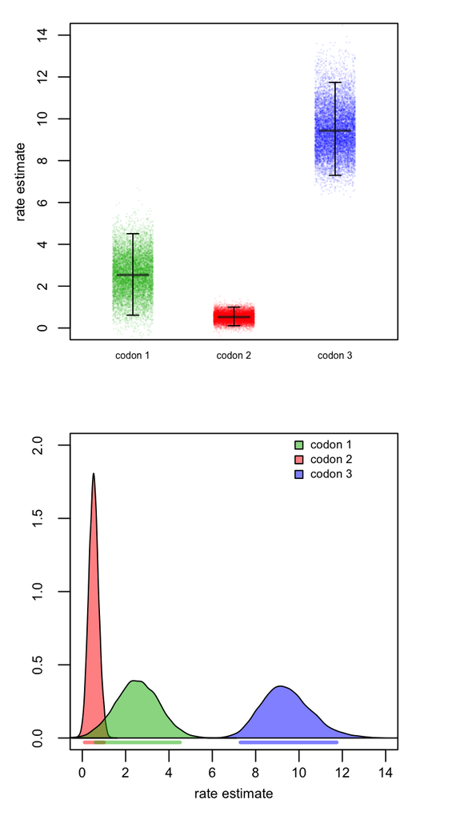

```r
# the par function is used to setup overall parameters of the
# plotting window that I am using.  In this case I use the mfcol
# argument to create a plot window with 2 rows and 1 column.
# I use the mar argument to set all margins to 3 except for the top
# margin which I set to 1.
par(mfcol=c(2,1), mar=c(3,3,1,3))

# in this first plot I want to jitter my data to the left
# and right so that it doesn't cover each other up a bit of
# experimentation showed me that a factor of 10 looked pretty
# good
xjit <- jitter(rep(0, 10000),factor=10)

# now I set up an empty plot box and supress
# both axes since I want to fine tune them later
plot(0, 0, col = "white",
     ylim = c(0, 14), xlim = c(.5, 3.5),
     xaxt = "n", xlab = "",
     yaxt = "n", ylab = "")

# now I plot my raw data for codon 1.  The rgb
# function gives me an easy way to supply a color
# and a transparency and gives R the hexadecimel
# version that it needs
points(y = dat$codon1,
       x = rep(1,10000) + xjit,
       pch = 16, cex = .2, col = rgb(0,.7,0,.1))

# now I do codon 2
points(y = dat$codon2,
       x = rep(2,10000) + xjit,
       pch = 16, cex = .2, col = rgb(1,0,0,.1))

# now I do codon 3
points(y = dat$codon3,
       x = rep(3,10000) + xjit,
       pch = 16, cex = .2, col = rgb(0,0,1,.1))

# This little loop is going to add whiskers and mean
# bars for each of the 3 codons
for(i in 1:3){

  # first I want to put whiskers that show what the
  # credible interval is.
  arrows(x0 = i, y0 = dat.sum[2, i],
         y1 = dat.sum[3, i],
         angle = 90, length = .05, code = 3)

  # now I add a thicker but lightly colored bar
  # for the mean
  lines(x = c(i - .15, i + .15),
        y = c(dat.sum[1, i], dat.sum[1, i]),
        lwd = 2, col=rgb(.1,.1,.1,.7))
}

# now I add on my X axis adjusting its size and spacing to
# my personal preference
axis(side = 1, at = c(1, 2, 3), tick = FALSE, line=-1,
     c("codon 1","codon 2","codon 3"), cex.axis = .5)

# I want my Y axis to be numbered at even values from 0 to 14 this
# creates that vector for me.
t.spot <- seq(from=0, to=14, by=2)

# now I do the same for the Y axis
axis(side = 2, at = t.spot, tick = TRUE, line=0,
     labels= t.spot, cex.axis = .7, padj =.5)
mtext(side=2, text="rate estimate", cex=.7, line=1.75)

# That completes one version of our plot.  This isn't a
# a very typical plot for this data but I kind of like it.

# This next one is how I would expect to see this type of dataset
# plotted in a good paper.

# again we set up a basic plot box and supress most aspects
plot(0, 0, col = "white",
     ylim = c(0, 2), xlim = c(0, 14),
     xaxt="n", xlab = "", ylab = "", cex.axis = .7)
# I want my axis to be numbered at even values from 0 to 14 this
# creates that vector for me.
t.spot <- seq(from=0, to=14, by=2)

# now I plot my x axis
axis(side = 1, at = t.spot,
     tick = TRUE, line = 0,
     labels = t.spot,
     cex.axis = .7,
     padj = -1.5)
mtext(side = 1, text = "rate estimate",
      cex = .7, line = 1.25)

# I use the polygon and density functions to show the
# posterior distributions that we have sampled.
polygon(density(dat$codon2), col = rgb(1,  0, 0, .5))
polygon(density(dat$codon1), col = rgb(0, .7, 0, .5))
polygon(density(dat$codon3), col = rgb(0,  0, 1, .5))

# on this plot I have decided to build a small custom legen
# inside of the plot window
points(x = 10, y = 2.0, pch = 22,
       col = "black",
       bg = rgb(0, .7, 0, .5))
points(x = 10, y = 1.9, pch = 22,
       col = "black",
       bg = rgb(1, 0, 0, .5))
points(x = 10, y = 1.8, pch = 22,
       col = "black",
       bg = rgb(0, 0, 1, .5))
text(x = 10, y = 2.0, "codon 1", cex = .6, pos = 4)
text(x = 10, y = 1.9, "codon 2", cex = .6, pos = 4)
text(x = 10, y = 1.8, "codon 3", cex = .6, pos = 4)

# to show the credible interval I will make lines under each distribution
lines(x = dat.sum$codon2[2:3], y = c(-.03, -.03),
      lwd = 3, col = rgb(1, 0, 0, .5))
lines(x = dat.sum$codon1[2:3], y = c(-.03, -.03),
      lwd = 3, col = rgb(0, .7, 0, .5))
lines(x = dat.sum$codon3[2:3], y = c(-.03, -.03),
      lwd = 3, col = rgb(0, 0, 1, .5))
```

## Getting your figures out of R…

Once you have gotten to this point you need to export your figures as some form of vector graphics (not JPG or BMP!). By using a vector format like EPS or PDF you will be able to enlarge your figures to any size necessary without pixelation. An additional benefit of vector graphics is that you can open them in programs like inkscape, or adobe acrobat and make any final minor changes necessary. The easiest way to do this is to click on the export button in the plot window. This will open a dialogue box and then select the file type you would like and the size of the image you want to save.

## Conclusion

As you can see it take a lot of code to make the figure just the way that I want it to look. However, your figures are one of the main things that people are going to look at in your papers. You will put your figures in all of your talks. People at conferences, in your department, at job interviews will all make judgement based on your figures. They are well worth spending the time to make just right.